# chapter6.Rmd

# 6.2.6 Creating a random intercept model for BPRSL data

```r
library(lme4)
BPRS_ref <- lmer(bprs ~ week + treatment + (1 | subject), data = BPRSL, REML = FALSE)
print(BPRS_ref)
```

```
## Linear mixed model fit by maximum likelihood  ['lmerMod']
## Formula: bprs ~ week + treatment + (1 | subject)
##    Data: BPRSL
##       AIC       BIC    logLik  deviance  df.resid
##  2748.712  2768.143 -1369.356  2738.712       355
## Random effects:
##  Groups   Name        Std.Dev.
##  subject  (Intercept)  6.885
##  Residual             10.208
## Number of obs: 360, groups:  subject, 20
## Fixed Effects:
## (Intercept)         week   treatment2
##     46.4539      -2.2704       0.5722
```

======================================================== We can fit the randrom intercept model for the same two explanatory variables: week and treatment. Fitting a random intercept model allows the linear regression fit for each subject to differ in intercept from other subjects. ========================================================

# 6.2.7 creating a random intercept and random slope model for BPRSL data

```r
BPRS_ref1 <- lmer(bprs ~ week + treatment + (week | subject), data = BPRSL, REML = FALSE)
print(BPRS_ref1)
```

```
## Linear mixed model fit by maximum likelihood  ['lmerMod']
## Formula: bprs ~ week + treatment + (week | subject)
##    Data: BPRSL
##       AIC       BIC    logLik  deviance  df.resid
##  2745.440  2772.643 -1365.720  2731.440       353
## Random effects:
##  Groups   Name        Std.Dev. Corr
##  subject  (Intercept) 8.0512
##           week        0.9803   -0.51
##  Residual             9.8707
## Number of obs: 360, groups:  subject, 20
## Fixed Effects:
## (Intercept)         week   treatment2
##     46.4539      -2.2704       0.5722
```

======================================================== We can also fit the ransom intercept and random slope model to the bprs data. Fitting a random intercept and random slope model allows the linear regression firs for each individual to differ in intercept but also in slope. It is possible to account for the individual difference in the subjects’ bprs profiles,but also the effect of time ========================================================

# 6.2.8 Performing an ANOVA test on the two models of BPRS data

```r
anova(BPRS_ref1, BPRS_ref)
```

```
## Data: BPRSL
## Models:
## BPRS_ref: bprs ~ week + treatment + (1 | subject)
## BPRS_ref1: bprs ~ week + treatment + (week | subject)
##           Df    AIC    BIC  logLik deviance  Chisq Chi Df Pr(>Chisq)
## BPRS_ref   5 2748.7 2768.1 -1369.4   2738.7
## BPRS_ref1  7 2745.4 2772.6 -1365.7   2731.4 7.2721      2    0.02636 *
## ---
## Signif. codes:  0 '***' 0.001 '**' 0.01 '*' 0.05 '.' 0.1 ' ' 1
```

============================================================================= BPRS_ref1 seem to fit better according to significance level of BPRS_fit1 and BPRS-fit ratio =============================================================================

# 6.2.9 Creating a random intercept and random slope model

```r
BPRS_ref2 <- lmer(bprs ~ week * treatment + (week | subject), data = BPRSL, REML = FALSE)
summary(BPRS_ref2)
```

```
## Linear mixed model fit by maximum likelihood  ['lmerMod']
## Formula: bprs ~ week * treatment + (week | subject)
##    Data: BPRSL
##
##      AIC      BIC   logLik deviance df.resid
##   2744.3   2775.4  -1364.1   2728.3      352
##
## Scaled residuals:
##     Min      1Q  Median      3Q     Max
## -3.0512 -0.6271 -0.0768  0.5288  3.9260
##
## Random effects:
##  Groups   Name        Variance Std.Dev. Corr
##  subject  (Intercept) 64.9964  8.0620
##           week         0.9687  0.9842   -0.51
##  Residual             96.4707  9.8220
## Number of obs: 360, groups:  subject, 20
##
## Fixed effects:
##                 Estimate Std. Error t value
## (Intercept)      47.8856     2.2521  21.262
## week             -2.6283     0.3589  -7.323
## treatment2       -2.2911     1.9090  -1.200
## week:treatment2   0.7158     0.4010   1.785
##
## Correlation of Fixed Effects:
##             (Intr) week   trtmn2
## week        -0.650
## treatment2  -0.424  0.469
## wek:trtmnt2  0.356 -0.559 -0.840
```

========================================================== With random intercept and slope model fit we can assess interaction between treatment and week. It looks like interaction model is not a better fir for bprs data ==========================================================

# 6.2.10 Perform an ANOVA test on the two models

```r
anova(BPRS_ref2, BPRS_ref1)
```

```
## Data: BPRSL
## Models:
## BPRS_ref1: bprs ~ week + treatment + (week | subject)
## BPRS_ref2: bprs ~ week * treatment + (week | subject)
##           Df    AIC    BIC  logLik deviance  Chisq Chi Df Pr(>Chisq)
## BPRS_ref1  7 2745.4 2772.6 -1365.7   2731.4
## BPRS_ref2  8 2744.3 2775.4 -1364.1   2728.3 3.1712      1    0.07495 .
## ---
## Signif. codes:  0 '***' 0.001 '**' 0.01 '*' 0.05 '.' 0.1 ' ' 1
```

# 6.2.11 Drawing the plot of BPRSL

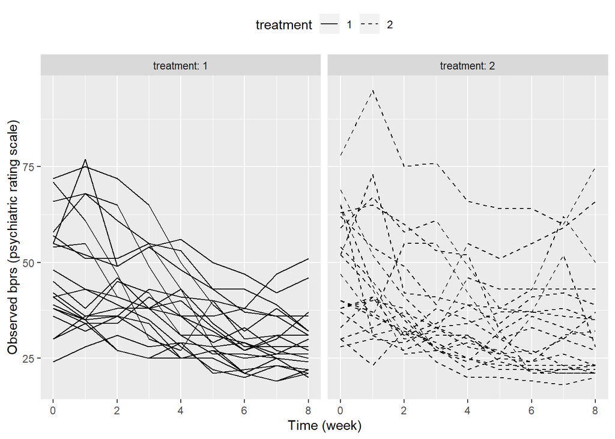

```r
ggplot(BPRSL, aes(x = week, y = bprs, treatment = subject)) +
  geom_line(aes(linetype = treatment))+
  scale_linetype_manual(values = rep(1:10, times=4)) +
  facet_grid(. ~ treatment, labeller = label_both) +
  scale_x_continuous(name = "Time (week)")+
  scale_y_continuous(name = "Observed bprs (psychiatric rating scale)") +
  theme(legend.position = "top")
```

# 6.2.12 Creating a vector of the fitted values

```r
Fitted <- fitted(BPRS_ref2)
```

# 6.2.13 Creating a new column fitted to BPRSL data

```r
BPRSL <- BPRSL %>%
  mutate(Fitted)
```

# 6.2.14 Drawing the plot of BPRSL

[figure not shown]

```r
ggplot(BPRSL, aes(x = week, y = bprs, treatment = subject)) +
  geom_line(aes(linetype = treatment))+
  scale_linetype_manual(values = rep(1:10, times=4)) +
  facet_grid(. ~ treatment, labeller = label_both) +
  scale_x_continuous(name = "Time (week)")+
  scale_y_continuous(name = "Fitted bprs (psychiatric rating scale)") +
  theme(legend.position = "top")
```